# **Computer Vision - HelmNet**

## **Problem Statement**

### **Business Context**

Workplace safety in hazardous environments like construction sites and industrial plants is crucial to prevent accidents and injuries. One of the most important safety measures is ensuring workers wear safety helmets, which protect against head injuries from falling objects and machinery. Non-compliance with helmet regulations increases the risk of serious injuries or fatalities, making effective monitoring essential, especially in large-scale operations where manual oversight is prone to errors and inefficiency.

To overcome these challenges, SafeGuard Corp plans to develop an automated image analysis system capable of detecting whether workers are wearing safety helmets. This system will improve safety enforcement, ensuring compliance and reducing the risk of head injuries. By automating helmet monitoring, SafeGuard aims to enhance efficiency, scalability, and accuracy, ultimately fostering a safer work environment while minimizing human error in safety oversight.

### **Objective**

As a data scientist at SafeGuard Corp, you are tasked with developing an image classification model that classifies images into one of two categories:

- **With Helmet:** Workers wearing safety helmets.
- **Without Helmet:** Workers not wearing safety helmets.

### **Data Description**

The dataset consists of **4125 images**, divided into two categories:

- **With Helmet:** 3161 images showing workers wearing helmets.
- **Without Helmet:** 964 images showing workers not wearing helmets.

**Dataset Characteristics:**

- **Variations in Conditions:** Images include diverse environments such as construction sites, factories, and industrial settings, with variations in lighting, angles, and worker postures to simulate real-world conditions.
- **Worker Activities:** Workers are depicted in different actions such as standing, using tools, or moving, ensuring robust model learning for various scenarios.

## **Installing and Importing the Necessary Libraries**

```python
# !pip install tensorflow[and-cuda] scikit-learn==1.6.1 opencv-python==4.12.0.88 seaborn==0.13.2 matplotlib==3.10.0 numpy==2.0.2 pandas==2.2.2 -q

# pip install tensorflow-macos tensorflow-metal
# pip install "numpy<2.0.0,>=1.26.0"
# pip install \
#     scikit-learn==1.6.1 \
#     opencv-python-headless==4.12.0.88 \
#     seaborn==0.13.2 \
#     matplotlib==3.10.0 \
#     pandas==2.2.2 \
#     scipy==1.17.1 \
#     --no-deps
```

```python
# Check TensorFlow version and GPU availability
import tensorflow as tf

print("TF:", tf.__version__)
print("GPU:", tf.config.list_physical_devices("GPU"))

# Check if TensorFlow is using the GPU
if tf.config.list_physical_devices("GPU"):
    print("TensorFlow is using the GPU.")
else:
    print("TensorFlow is not using the GPU.")
print("Num GPUs Available:", len(tf.config.list_physical_devices('GPU')))
```

```
TF: 2.16.2
GPU: [PhysicalDevice(name='/physical_device:GPU:0', device_type='GPU')]
TensorFlow is using the GPU.
Num GPUs Available: 1
```

```python
import os
import random
import numpy as np                     # Numerical operations and array handling
import pandas as pd                    # Tabular data loading and manipulation
import seaborn as sns                  # Statistical plotting (heatmaps, confusion matrices)
import matplotlib.image as mpimg       # Loading and displaying images
import matplotlib.pyplot as plt        # Plotting utilities

# TensorFlow / Keras core modules
import keras
import tensorflow as tf
from tensorflow.keras.models import Sequential                        # Sequential model API
from tensorflow.keras.optimizers import Adam                          # Optimizer used for training
from tensorflow.keras.preprocessing.image import ImageDataGenerator       # Data augmentation and preprocessing

# Scikit‑learn utilities
from sklearn import preprocessing                                      # Label encoding, scaling, etc.
from sklearn.model_selection import train_test_split                   # Train/validation/test splitting
from sklearn.utils import compute_class_weight                 # Compute class weights for imbalanced datasets

# Pretrained model
from keras.applications.vgg16 import VGG16                             # VGG16 base model for transfer learning

# Keras layers
from tensorflow.keras.layers import (
    Dense, Dropout, Flatten, Conv2D, MaxPooling2D               # Core CNN layers
)

# Evaluation metrics
from sklearn.metrics import (
    precision_score,
    recall_score,
    f1_score,
    average_precision_score,           # PR‑AUC calculation
    roc_auc_score,                    # ROC‑AUC calculation
    classification_report,
    confusion_matrix                 # Confusion matrix for detailed error analysis
)
from tensorflow.keras.metrics import AUC   # PR‑AUC and ROC‑AUC during training

# Suppress warnings and TensorFlow logs
import warnings
warnings.filterwarnings('ignore')
os.environ["TF_CPP_MIN_LOG_LEVEL"] = "3"
```

```python
# Set random seeds for reproducibility
SEED = 812

# 1. Set Python random seed for dataset shuffling, sampling
random.seed(SEED)

# 2. Set NumPy random seed for preprocessing, augmentations, and any NumPy-based operations
np.random.seed(SEED)

# 3. Set TensorFlow seed (covers Keras + backend) for weight init, dropout, training, and any TF-based operations
tf.keras.utils.set_random_seed(SEED)

# 4. Enable deterministic TensorFlow operations
tf.config.experimental.enable_op_determinism()
```

## **Data Overview**

### Loading the data

```python
# Load the dataset
images = np.load("images.npy")
labels_df = pd.read_csv("labels.csv")

labels = labels_df["label"].values

print("Images shape:", images.shape)
print("Labels shape:", labels.shape)
print(labels_df.head())
print(labels_df["label"].value_counts())
```

```
Images shape: (4125, 200, 200, 3)
Labels shape: (4125,)
   label
0      0
1      0
2      0
3      0
4      0
label
1    3161
0     964
Name: count, dtype: int64
```

**Observation**

The dataset consists of 4,125 RGB images (200×200 pixels) with corresponding labels, showing a class imbalance with 3,161 “With Helmet” and 964 “Without Helmet” samples.

## **Exploratory Data Analysis**

```python
# Define class names for better readability in confusion matrix and classification report

class_names = {
    0: "Without Helmet",
    1: "With Helmet"
}
```

### Plot random images from each of the classes and print their corresponding labels.

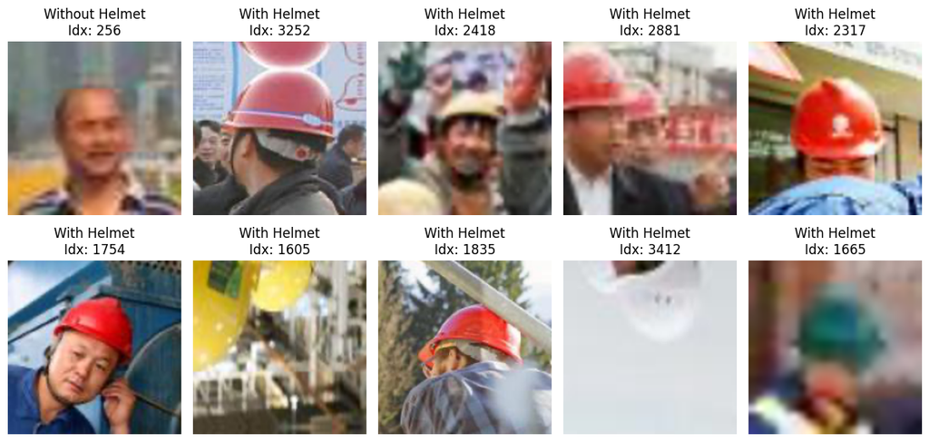

```python
# Visualize some random images from the dataset
plt.figure(figsize=(12, 6))

for i in range(10):
    idx = random.randint(0, len(images) - 1)
    plt.subplot(2, 5, i + 1)
    plt.imshow(images[idx])
    plt.title(f"{class_names[labels[idx]]}\nIdx: {idx}")
    plt.axis("off")

plt.tight_layout()
plt.show()
```

**Observations**

- The dataset contains diverse real‑world conditions—varying lighting, angles, and environments—making it suitable for building a robust deployment‑ready model. Blurred, partially visible workers and helmets highlight the need for resilience to imperfect visuals, while ambiguous or noisy samples reinforce the value of stronger architectures such as transfer learning.

### Plotting class imbalance

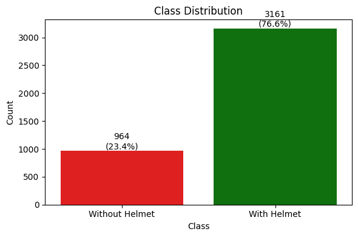

```python
# Check class distribution

plt.figure(figsize=(6, 4))

ax = sns.countplot(x=labels, palette=['red', 'green'])

# Apply class names
ax.set_xticklabels([class_names[i] for i in sorted(class_names)])

# Add count + %
total = len(labels)
for p in ax.patches:
    ax.annotate(f'{int(p.get_height())}\n({p.get_height()/total:.1%})',
                (p.get_x() + p.get_width()/2, p.get_height()),
                ha='center', va='bottom')

plt.title("Class Distribution")
plt.xlabel("Class")
plt.ylabel("Count")
plt.tight_layout()
plt.show()
```

**Observation**

- TThe dataset is clearly imbalanced, with 76.6% “With Helmet” and 23.4% “Without Helmet.” Because accuracy would be misleading under this skew, evaluation must rely on recall, precision, F1‑score, and the confusion matrix. The imbalance also reinforces the need for models capable of handling challenging real‑world variability—such as transfer‑learning architectures—to ensure reliable detection of the safety‑critical “Without Helmet” cases.

## **Data Preprocessing**

The EDA highlights key dataset characteristics—imbalance, variable image quality, and noisy samples—which directly shape the preprocessing strategy. Each preprocessing step ensures consistent class representation, stable model training, and reliable evaluation under real‑world conditions.

| Step | What to Do | Why (Based on EDA) |
| --- | --- | --- |
| Train/Validation/Test Split | Split data into train, validation, and test sets using **stratified sampling** | Dataset is **imbalanced**, so stratification preserves class proportions across all splits |
| Normalization | Scale pixel values from **0–255 to 0–1** | Images vary in **lighting and quality**, so normalization stabilizes training and improves convergence |
| Validation Set Creation | Keep a separate validation set during training | **Noisy and ambiguous samples** increase overfitting risk; validation helps monitor generalization |
| Test Set Reservation | Hold out a final test set for evaluation | Ensures **unbiased performance assessment** on unseen data, reflecting real deployment conditions |

```python
# Function to prepare image data for training, validation, and testing (including  data splitting and normalisation)

def prepare_image_data(images, labels, test_size=0.30, val_size=0.50, random_state=42):
    """
    Split image data into train, validation, and test sets, then normalise pixel values.

    Final split:
    - 70% train
    - 15% validation
    - 15% test
    """

    # Ensure correct types
    X_raw = np.asarray(images, dtype="float32")
    y = np.asarray(labels, dtype="int32")

    # First split: train and temporary set
    X_train, X_temp, y_train, y_temp = train_test_split(
        X_raw,
        y,
        test_size=test_size,
        stratify=y,
        random_state=random_state
    )

    # Second split: validation and test
    X_val, X_test, y_val, y_test = train_test_split(
        X_temp,
        y_temp,
        test_size=val_size,
        stratify=y_temp,
        random_state=random_state
    )

    # Normalise pixel values: 0–255 → 0–1
    X_train_norm = X_train / 255.0
    X_val_norm = X_val / 255.0
    X_test_norm = X_test / 255.0

    # Print shapes
    for name, arr in {
        "X_train": X_train,
        "X_val": X_val,
        "X_test": X_test,
        "y_train": y_train,
        "y_val": y_val,
        "y_test": y_test
    }.items():
        print(f"{name}: {arr.shape}")

    # Check normalisation
    print("\nPixel value ranges after normalisation:")
    print("Train min/max:", X_train_norm.min(), X_train_norm.max())
    print("Validation min/max:", X_val_norm.min(), X_val_norm.max())
    print("Test min/max:", X_test_norm.min(), X_test_norm.max())

    return X_train_norm, X_val_norm, X_test_norm, y_train, y_val, y_test
```

```python
# Prepare the data

X_train_norm, X_val_norm, X_test_norm, y_train, y_val, y_test = prepare_image_data(
    images,
    labels
)
```

```
X_train: (2887, 200, 200, 3)
X_val: (619, 200, 200, 3)
X_test: (619, 200, 200, 3)
y_train: (2887,)
y_val: (619,)
y_test: (619,)

Pixel value ranges after normalisation:
Train min/max: 0.0 1.0
Validation min/max: 0.0 1.0
Test min/max: 0.0 1.0
```

**Observation**

- The data is split into train, validation, and test sets with consistent shapes across all splits, each resized to 200×200×3. After normalization, pixel values in every subset fall cleanly within the 0–1 range, confirming that preprocessing was applied correctly and uniformly. With the data now structured and scaled, it is ready to be fed into the model‑building stage.

## **Model Building**

- With the data prepared and normalized, the next step is to build and evaluate models for classifying workers as *With Helmet* or *Without Helmet*.
- The dataset’s imbalance and visual variability guide the progression from simple baselines to stronger transfer‑learning models, helping identify the most reliable option for safety monitoring.
- Performance is evaluated using validation metrics, confusion matrices, and class‑specific precision, recall, and F1‑scores, since missing an unprotected worker carries real safety consequences.
- Flatten is used after the VGG16 base to retain the full spatial feature representation learned during feature extraction, supporting stronger downstream classification.

### Models Overview

- Four models were developed progressively, starting with a simple CNN and advancing to VGG16‑based transfer learning. This staged approach shows how feature extraction, model depth, and augmentation improve robustness in detecting helmet compliance.

| Model | Description | Purpose | Expected Outcome |
| --- | --- | --- | --- |
| **CNN** | Basic custom CNN | Establish baseline | Moderate, risk of overfitting |
| **VGG16 (Base)** | Frozen VGG16 + simple head | Use pretrained features | Better than baseline |
| **VGG16 + FFNN** | VGG16 + dense layers | Stronger task‑specific learning | Higher precision/recall |
| **VGG16 + FFNN + Aug** | Same model + augmentation | Improve robustness | Best generalisation |

- This progression directly addresses dataset variability, noise, and imbalance.

### Threshold Strategy & Training Hyperparameters

Lower thresholds boost recall but increase false alarms, while higher thresholds improve precision but risk missing unsafe workers. Because the dataset is imbalanced and the minority class represents the highest‑risk category, the final threshold was selected through tuning during training to prioritise high recall with acceptable precision.

| Hyperparameter | Reasoning |
| --- | --- |
| **Epochs = 20** | Sufficient learning; EarlyStopping prevents overfitting |
| **Batch Size = 32** | Stable gradients and efficient updates |
| **Dropout = 0.3–0.5** | Controls overfitting in a small, imbalanced dataset |

These settings support stable learning and stronger generalisation under class imbalance.

```python
# Define a shared configuration (learning rate, loss, batch size, epochs) to ensure fair comparison across models.
learning_rate = 0.0001
loss = "binary_crossentropy"
batch_size = 32
epochs = 20
```

#### Early stopping callback

```python
# Early stopping was used to prevent overfitting and allow each model to converge at its optimal point.
early_stop = tf.keras.callbacks.EarlyStopping(
    monitor="val_pr_auc",
    mode="max",
    patience=5,
    restore_best_weights=True
)
```

### Model Evaluation Criterion

- Evaluation focuses on detecting No Helmet cases—the highest‑risk class. Metrics emphasise recall, false negatives, and PR‑AUC to ensure unsafe workers are not missed

| Metric | Why It Matters | Desired Direction | Priority |
| --- | --- | --- | --- |
| **PR-AUC** | Measures minority-class detection performance in imbalanced data | **Higher is better** | **Critical** |
| **Recall (No Helmet)** | Measures how well unsafe workers are detected | **Higher is better** | **Highest** |
| **False Positives (FP)** | Unsafe workers incorrectly classified as safe workers | **Lower is better** | **Highest** |
| **F1-Score** | Balances recall and precision | **Higher is better** | High |
| **False Negatives (FN)** | Safe workers incorrectly flagged as unsafe | **Lower is better** | High |
| **Precision** | Measures reliability of unsafe-worker predictions | **Higher is better** | Medium |
| **ROC-AUC** | Measures overall class separation ability | **Higher is better** | Supporting |
| **Confusion Matrix** | Shows real-world classification outcomes | Context-dependent | Supporting |
| **Training Curves** | Helps identify overfitting or unstable learning | Stable convergence preferred | Supporting |

**Final focus: Recall, FN, PR‑AUC, F1, Precision.** Accuracy excluded due to imbalance.

### Utility Functions

```python
# function to visualize predictions of the model

def visualize_predictions(model, X_data, y_data, class_names, n=10):
    """
    Display sample images with actual and predicted labels.
    """
    y_prob = model.predict(X_data)
    y_pred = (y_prob > 0.5).astype("int32").reshape(-1)
    y_true = np.asarray(y_data).reshape(-1)

    indices = np.random.choice(len(X_data), size=n, replace=False)

    plt.figure(figsize=(15, 6))

    for i, idx in enumerate(indices):
        plt.subplot(2, 5, i + 1)
        plt.imshow(X_data[idx])

        actual = class_names[y_true[idx]]
        predicted = class_names[y_pred[idx]]

        plt.title(
            f"Actual: {actual}\nPred: {predicted}",
            fontsize=9
        )
        plt.axis("off")

    plt.tight_layout()
    plt.show()
```

```python
# Function to plot training history of the model, including accuracy, PR-AUC, and loss curves for both training and validation sets.

def plot_training_history(history, model_name):
    """
    Plot training and validation metrics dynamically:
    - Accuracy (if available)
    - Recall (if available)
    - PR-AUC
    - Loss
    Returns best validation PR-AUC.
    """

    # Determine which metrics exist
    has_accuracy = "accuracy" in history.history
    has_recall = "recall" in history.history

    # Count how many subplots we need
    num_plots = 2  # PR-AUC + Loss are always present
    if has_accuracy:
        num_plots += 1
    if has_recall:
        num_plots += 1

    plt.figure(figsize=(5 * num_plots, 4))
    plot_index = 1

    # Accuracy
    if has_accuracy:
        plt.subplot(1, num_plots, plot_index)
        plt.plot(history.history["accuracy"], label="Training Accuracy")
        plt.plot(history.history["val_accuracy"], label="Validation Accuracy")
        plt.title(f"{model_name} - Accuracy")
        plt.xlabel("Epoch")
        plt.ylabel("Accuracy")
        plt.legend()
        plot_index += 1

    # Recall
    if has_recall:
        plt.subplot(1, num_plots, plot_index)
        plt.plot(history.history["recall"], label="Training Recall")
        plt.plot(history.history["val_recall"], label="Validation Recall")
        plt.title(f"{model_name} - Recall")
        plt.xlabel("Epoch")
        plt.ylabel("Recall")
        plt.legend()
        plot_index += 1

    # PR-AUC
    plt.subplot(1, num_plots, plot_index)
    plt.plot(history.history["pr_auc"], label="Training PR-AUC")
    plt.plot(history.history["val_pr_auc"], label="Validation PR-AUC")
    plt.title(f"{model_name} - PR-AUC")
    plt.xlabel("Epoch")
    plt.ylabel("PR-AUC")
    plt.legend()
    plot_index += 1

    # Loss
    plt.subplot(1, num_plots, plot_index)
    plt.plot(history.history["loss"], label="Training Loss")
    plt.plot(history.history["val_loss"], label="Validation Loss")
    plt.title(f"{model_name} - Loss")
    plt.xlabel("Epoch")
    plt.ylabel("Loss")
    plt.legend()

    plt.tight_layout()
    plt.show()

    best_val_pr_auc = max(history.history["val_pr_auc"])
    print(f"Best Validation PR-AUC ({model_name}): {best_val_pr_auc:.4f}")

    return best_val_pr_auc
```

```python
# Function to find the best threshold for classifying 'Without Helmet' class based on precision, recall, and F1-score

def find_best_threshold_no_helmet(y_true, y_prob, min_precision=0.50):
    """
    Find best threshold for detecting 'Without Helmet' class.
    Label mapping:
    0 = Without Helmet
    1 = With Helmet
    """

    y_true = np.asarray(y_true).reshape(-1).astype(int)

    # Convert to "No Helmet as positive"
    y_true_no_helmet = 1 - y_true
    y_prob_no_helmet = 1 - y_prob

    thresholds = np.arange(0.10, 0.91, 0.05)
    results = []

    for threshold in thresholds:
        y_pred_no_helmet = (y_prob_no_helmet >= threshold).astype(int)

        precision = precision_score(y_true_no_helmet, y_pred_no_helmet, zero_division=0)
        recall = recall_score(y_true_no_helmet, y_pred_no_helmet, zero_division=0)
        f1 = f1_score(y_true_no_helmet, y_pred_no_helmet, zero_division=0)

        results.append({
            "threshold": threshold,
            "precision": precision,
            "recall": recall,
            "f1": f1
        })

    threshold_df = pd.DataFrame(results)

    valid_thresholds = threshold_df[threshold_df["precision"] >= min_precision]

    if len(valid_thresholds) > 0:
        best_row = valid_thresholds.sort_values(
            by=["recall", "f1", "precision"],
            ascending=False
        ).iloc[0]
    else:
        best_row = threshold_df.sort_values(
            by=["f1", "recall", "precision"],
            ascending=False
        ).iloc[0]

    return best_row["threshold"], threshold_df
```

```python
# Function to evaluate the model's performance

def evaluate_model(model, X_data, y_data, model_name, min_precision=0.50):
    """
    Evaluate helmet classification model with threshold tuning
    focused on the 'Without Helmet' class.
    """

    y_prob = model.predict(X_data).ravel()
    y_prob = np.nan_to_num(y_prob, nan=0.0, posinf=1.0, neginf=0.0)

    y_true = np.asarray(y_data).reshape(-1).astype(int)

    best_threshold, threshold_df = find_best_threshold_no_helmet(
        y_true,
        y_prob,
        min_precision=min_precision
    )

    # Convert model probability for class 1 into probability for class 0
    y_prob_no_helmet = 1 - y_prob

    # Predict No Helmet using tuned threshold
    y_pred_no_helmet = (y_prob_no_helmet >= best_threshold).astype(int)

    # Convert back to original labels:
    # no_helmet=1 -> original class 0
    # no_helmet=0 -> original class 1
    y_pred = 1 - y_pred_no_helmet

    cm = confusion_matrix(y_true, y_pred, labels=[0, 1])
    tn, fp, fn, tp = cm.ravel()

    recall_no_helmet = recall_score(y_true, y_pred, pos_label=0, zero_division=0)
    precision_no_helmet = precision_score(y_true, y_pred, pos_label=0, zero_division=0)
    f1_no_helmet = f1_score(y_true, y_pred, pos_label=0, zero_division=0)

    pr_auc_no_helmet = average_precision_score(1 - y_true, 1 - y_prob)
    roc_auc_no_helmet = roc_auc_score(1 - y_true, 1 - y_prob) if len(np.unique(y_true)) == 2 else np.nan

    print(f"\nModel: {model_name}")
    print(f"Best Threshold (Without Helmet): {best_threshold:.2f}")
    print(f"PR-AUC :        {pr_auc_no_helmet:.4f}")
    print(f"ROC-AUC :       {roc_auc_no_helmet:.4f}")
    print(f"Recall (Without Helmet):        {recall_no_helmet:.4f}")
    print(f"F1 Score (Without Helmet):      {f1_no_helmet:.4f}")
    print(f"Precision (Without Helmet):     {precision_no_helmet:.4f}")


    print("\nClassification Report:")
    print(classification_report(
        y_true,
        y_pred,
        labels=[0, 1],
        target_names=["Without Helmet", "With Helmet"],
        zero_division=0
    ))

    plt.figure(figsize=(6, 5))
    sns.heatmap(
        cm,
        annot=True,
        fmt="d",
        cmap="Blues",
        xticklabels=["Without Helmet", "With Helmet"],
        yticklabels=["Without Helmet", "With Helmet"]
    )
    plt.title(f"{model_name} - Confusion Matrix")
    plt.xlabel("Predicted")
    plt.ylabel("Actual")
    plt.tight_layout()
    plt.show()

    return {
        "model_name": model_name,
        "threshold": best_threshold,
        "recall": recall_no_helmet,
        "pr_auc": pr_auc_no_helmet,
        "f1": f1_no_helmet,
        "precision": precision_no_helmet,
        "roc_auc": roc_auc_no_helmet,
        "tn": tn,
        "fp": fp,
        "fn": fn,
        "tp": tp,
        "threshold_df": threshold_df
    }
```

### Model 1: Convolutional Neural Network (CNN)

The modelling process begins with a CNN built from scratch, providing a strong baseline and demonstrating that a lightweight architecture can already achieve high recall and stable separation between helmet and non‑helmet cases when paired with careful threshold tuning.

This baseline consists of two parts: convolutional layers that extract visual features from the images, and fully connected layers that use those features to classify each worker as either *With Helmet* or *Without Helmet*.

```python
# Define a simple CNN model from scratch

# 1. Define model
cnn_model = Sequential([
    Conv2D(32, (3, 3), activation="relu", padding="same", input_shape=(200, 200, 3)),
    MaxPooling2D(2, 2),

    Conv2D(64, (3, 3), activation="relu", padding="same"),
    MaxPooling2D(2, 2),

    Conv2D(128, (3, 3), activation="relu", padding="same"),
    MaxPooling2D(2, 2),

    Flatten(),
    Dense(128, activation="relu"),
    Dropout(0.5),

    Dense(1, activation="sigmoid")
])

# 2. # Compile the model using a consistent configuration (same optimizer, loss, and metrics as other models for fair comparison).

cnn_model.compile(
    optimizer=Adam(learning_rate=learning_rate, clipnorm=1.0),
    loss=loss,
    metrics=['recall', AUC(name="pr_auc", curve="PR") ]
)

# 3. Train the model with early stopping to prevent overfittin and class weights to address imbalance.
history_cnn = cnn_model.fit(
    X_train_norm,
    y_train,
    validation_data=(X_val_norm, y_val),
    epochs=epochs,
    batch_size=batch_size,
    callbacks=[early_stop],
    verbose=2
)
```

```
91/91 - 10s - 115ms/step - loss: 0.5964 - pr_auc: 0.8261 - recall: 0.9204 - val_loss: 0.4310 - val_pr_auc: 0.9665 - val_recall: 1.0000
91/91 - 7s - 78ms/step - loss: 0.5283 - pr_auc: 0.9110 - recall: 0.9575 - val_loss: 0.5597 - val_pr_auc: 0.9777 - val_recall: 1.0000
91/91 - 6s - 71ms/step - loss: 0.6555 - pr_auc: 0.9129 - recall: 0.9344 - val_loss: 0.3039 - val_pr_auc: 0.9803 - val_recall: 0.9853
91/91 - 6s - 68ms/step - loss: 0.6629 - pr_auc: 0.9284 - recall: 0.9195 - val_loss: 0.2572 - val_pr_auc: 0.9793 - val_recall: 0.9705
91/91 - 6s - 67ms/step - loss: 0.6345 - pr_auc: 0.9434 - recall: 0.9236 - val_loss: 0.2782 - val_pr_auc: 0.9813 - val_recall: 0.9684
91/91 - 6s - 70ms/step - loss: 0.6315 - pr_auc: 0.9469 - recall: 0.9250 - val_loss: 0.2576 - val_pr_auc: 0.9829 - val_recall: 0.9516
91/91 - 6s - 68ms/step - loss: 0.6488 - pr_auc: 0.9495 - recall: 0.9195 - val_loss: 0.3353 - val_pr_auc: 0.9768 - val_recall: 0.9705
91/91 - 6s - 66ms/step - loss: 0.6065 - pr_auc: 0.9549 - recall: 0.9290 - val_loss: 0.3040 - val_pr_auc: 0.9787 - val_recall: 0.9579
91/91 - 6s - 66ms/step - loss: 0.4818 - pr_auc: 0.9617 - recall: 0.9313 - val_loss: 0.2851 - val_pr_auc: 0.9801 - val_recall: 0.9516
91/91 - 6s - 66ms/step - loss: 0.5529 - pr_auc: 0.9585 - recall: 0.9263 - val_loss: 0.3120 - val_pr_auc: 0.9804 - val_recall: 0.9537
91/91 - 6s - 68ms/step - loss: 0.5076 - pr_auc: 0.9600 - recall: 0.9363 - val_loss: 0.3590 - val_pr_auc: 0.9756 - val_recall: 0.9663
```

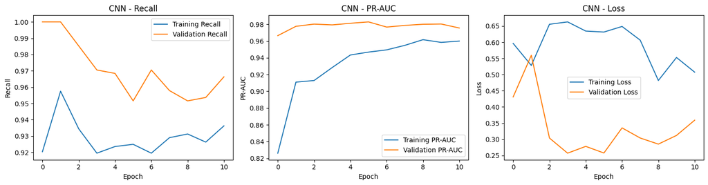

```
Best Validation PR-AUC (CNN): 0.9829
20/20 ━━━━━━━━━━━━━━━━━━━━ 1s 18ms/step

Model: CNN
Best Threshold (Without Helmet): 0.10
PR-AUC :        0.8942
ROC-AUC :       0.9636
Recall (Without Helmet):        0.9236
F1 Score (Without Helmet):      0.8210
Precision (Without Helmet):     0.7389

Classification Report:
                precision    recall  f1-score   support

Without Helmet       0.74      0.92      0.82       144
   With Helmet       0.97      0.90      0.94       475

      accuracy                           0.91       619
     macro avg       0.86      0.91      0.88       619
  weighted avg       0.92      0.91      0.91       619
```

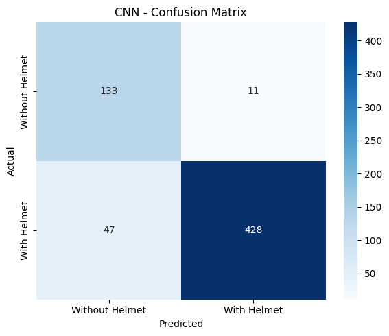

```python
#  4. Evaluate the CNN model on the validation set and store results

cnn_pr_auc = plot_training_history(history_cnn, "CNN")

cnn_results = evaluate_model( cnn_model, X_val_norm, y_val, "CNN")
```

**CNN — Performance Summary**

- The model demonstrated strong overall classification performance, achieving a validation PR-AUC of **0.9829** and a ROC-AUC of **0.9636**.
- The model achieved an overall validation accuracy of **91%**, indicating effective learning of helmet and non-helmet patterns.
- Performance on the critical **Without Helmet** class was strong, with a recall of **0.9236**, showing the model was able to detect most unsafe workers correctly.
- Precision for the **Without Helmet** class reached **0.7389**, indicating that although some false alarms remained, the model maintained a reasonable balance between sensitivity and reliability.
- The resulting F1-score of **0.8210** reflected a good trade-off between recall and precision for the safety-critical class.
- Overall, the model showed strong potential for helmet detection tasks, particularly where prioritising unsafe-worker detection is important.

#### Visualizing the predictions

```
20/20 ━━━━━━━━━━━━━━━━━━━━ 0s 15ms/step
```

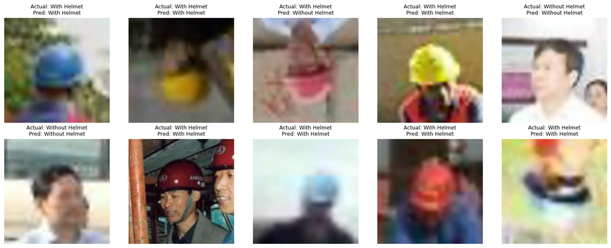

```python
visualize_predictions(cnn_model, X_val_norm, y_val, class_names)
```

**CNN – Prediction Visualisation Summary**

- The model correctly classified most helmet and non-helmet cases despite low-resolution and blurred images.
- Strong performance was observed on clear frontal and side-view helmet images.
- Some misclassifications occurred in heavily blurred or low-quality images where helmet features were less distinguishable.
- The model showed good robustness to variations in lighting, colour, and viewing angles.
- Overall, predictions indicate the model learned meaningful helmet-related visual patterns from the dataset.

### Model 2: Transfer Learning with VGG-16 (Base)

To improve feature extraction beyond what the baseline CNN could capture, the next model adopts VGG16 as a frozen feature extractor, combined with a simple Flatten + Dense head to test whether pretrained ImageNet features can enhance recall for the minority Without Helmet class.

```python
# Define a transfer learning model using VGG16 as the base
vgg_model = VGG16(  weights="imagenet", include_top=False, input_shape=(200, 200, 3) )

# Freeze pretrained layers
for layer in vgg_model.layers:
    layer.trainable = False

vgg_model.summary()
```

```
Model: "vgg16"
```

```
┏━━━━━━━━━━━━━━━━━━━━━━━━━━━━━━━━━┳━━━━━━━━━━━━━━━━━━━━━━━━┳━━━━━━━━━━━━━━━┓
┃ Layer (type)                    ┃ Output Shape           ┃       Param # ┃
┡━━━━━━━━━━━━━━━━━━━━━━━━━━━━━━━━━╇━━━━━━━━━━━━━━━━━━━━━━━━╇━━━━━━━━━━━━━━━┩
│ input_layer_1 (InputLayer)      │ (None, 200, 200, 3)    │             0 │
├─────────────────────────────────┼────────────────────────┼───────────────┤
│ block1_conv1 (Conv2D)           │ (None, 200, 200, 64)   │         1,792 │
├─────────────────────────────────┼────────────────────────┼───────────────┤
│ block1_conv2 (Conv2D)           │ (None, 200, 200, 64)   │        36,928 │
├─────────────────────────────────┼────────────────────────┼───────────────┤
│ block1_pool (MaxPooling2D)      │ (None, 100, 100, 64)   │             0 │
├─────────────────────────────────┼────────────────────────┼───────────────┤
│ block2_conv1 (Conv2D)           │ (None, 100, 100, 128)  │        73,856 │
├─────────────────────────────────┼────────────────────────┼───────────────┤
│ block2_conv2 (Conv2D)           │ (None, 100, 100, 128)  │       147,584 │
├─────────────────────────────────┼────────────────────────┼───────────────┤
│ block2_pool (MaxPooling2D)      │ (None, 50, 50, 128)    │             0 │
├─────────────────────────────────┼────────────────────────┼───────────────┤
│ block3_conv1 (Conv2D)           │ (None, 50, 50, 256)    │       295,168 │
├─────────────────────────────────┼────────────────────────┼───────────────┤
│ block3_conv2 (Conv2D)           │ (None, 50, 50, 256)    │       590,080 │
├─────────────────────────────────┼────────────────────────┼───────────────┤
│ block3_conv3 (Conv2D)           │ (None, 50, 50, 256)    │       590,080 │
├─────────────────────────────────┼────────────────────────┼───────────────┤
│ block3_pool (MaxPooling2D)      │ (None, 25, 25, 256)    │             0 │
├─────────────────────────────────┼────────────────────────┼───────────────┤
│ block4_conv1 (Conv2D)           │ (None, 25, 25, 512)    │     1,180,160 │
├─────────────────────────────────┼────────────────────────┼───────────────┤
│ block4_conv2 (Conv2D)           │ (None, 25, 25, 512)    │     2,359,808 │
├─────────────────────────────────┼────────────────────────┼───────────────┤
│ block4_conv3 (Conv2D)           │ (None, 25, 25, 512)    │     2,359,808 │
├─────────────────────────────────┼────────────────────────┼───────────────┤
│ block4_pool (MaxPooling2D)      │ (None, 12, 12, 512)    │             0 │
├─────────────────────────────────┼────────────────────────┼───────────────┤
│ block5_conv1 (Conv2D)           │ (None, 12, 12, 512)    │     2,359,808 │
├─────────────────────────────────┼────────────────────────┼───────────────┤
│ block5_conv2 (Conv2D)           │ (None, 12, 12, 512)    │     2,359,808 │
├─────────────────────────────────┼────────────────────────┼───────────────┤
│ block5_conv3 (Conv2D)           │ (None, 12, 12, 512)    │     2,359,808 │
├─────────────────────────────────┼────────────────────────┼───────────────┤
│ block5_pool (MaxPooling2D)      │ (None, 6, 6, 512)      │             0 │
└─────────────────────────────────┴────────────────────────┴───────────────┘
```

```
 Total params: 14,714,688 (56.13 MB)
```

```
 Trainable params: 0 (0.00 B)
```

```
 Non-trainable params: 14,714,688 (56.13 MB)
```

```python
# Define a transfer learning model using VGG16 as the base

# 1. Define model
vgg16_base_model = Sequential([
    vgg_model,  # Adding the convolutional part of the VGG16 model
    Flatten(),
    Dense(1, activation="sigmoid")  # Output layer
])

vgg16_base_model.summary()

# 2. Compile model
vgg16_base_model.compile(
    optimizer=Adam(learning_rate=learning_rate, clipnorm=1.0),
    loss=loss,
    metrics=['recall', AUC(name="pr_auc", curve="PR") ]
)

# 3. Train model directly on normalized training data
history_vgg16_base = vgg16_base_model.fit(
    X_train_norm,
    y_train,
    validation_data=(X_val_norm, y_val),
    epochs=epochs,
    batch_size=batch_size,
    callbacks=[early_stop],
    verbose=2
)
```

```
Model: "sequential_1"
```

```
┏━━━━━━━━━━━━━━━━━━━━━━━━━━━━━━━━━┳━━━━━━━━━━━━━━━━━━━━━━━━┳━━━━━━━━━━━━━━━┓
┃ Layer (type)                    ┃ Output Shape           ┃       Param # ┃
┡━━━━━━━━━━━━━━━━━━━━━━━━━━━━━━━━━╇━━━━━━━━━━━━━━━━━━━━━━━━╇━━━━━━━━━━━━━━━┩
│ vgg16 (Functional)              │ (None, 6, 6, 512)      │    14,714,688 │
├─────────────────────────────────┼────────────────────────┼───────────────┤
│ flatten_1 (Flatten)             │ (None, 18432)          │             0 │
├─────────────────────────────────┼────────────────────────┼───────────────┤
│ dense_2 (Dense)                 │ (None, 1)              │        18,433 │
└─────────────────────────────────┴────────────────────────┴───────────────┘
```

```
 Total params: 14,733,121 (56.20 MB)
```

```
 Trainable params: 18,433 (72.00 KB)
```

```
 Non-trainable params: 14,714,688 (56.13 MB)
```

```
91/91 - 21s - 230ms/step - loss: 0.4918 - pr_auc: 0.8994 - recall: 0.9896 - val_loss: 0.4252 - val_pr_auc: 0.9548 - val_recall: 0.9958
91/91 - 19s - 204ms/step - loss: 0.3813 - pr_auc: 0.9693 - recall: 0.9941 - val_loss: 0.3702 - val_pr_auc: 0.9682 - val_recall: 0.9895
91/91 - 18s - 201ms/step - loss: 0.3277 - pr_auc: 0.9776 - recall: 0.9864 - val_loss: 0.3406 - val_pr_auc: 0.9719 - val_recall: 0.9789
91/91 - 19s - 204ms/step - loss: 0.2953 - pr_auc: 0.9817 - recall: 0.9810 - val_loss: 0.3228 - val_pr_auc: 0.9738 - val_recall: 0.9705
91/91 - 18s - 199ms/step - loss: 0.2730 - pr_auc: 0.9841 - recall: 0.9783 - val_loss: 0.3106 - val_pr_auc: 0.9755 - val_recall: 0.9663
```

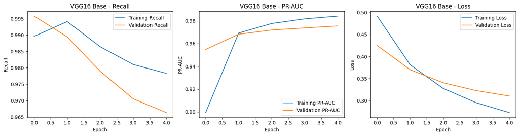

```
Best Validation PR-AUC (VGG16 Base): 0.9755
20/20 ━━━━━━━━━━━━━━━━━━━━ 3s 156ms/step

Model: VGG16 Base
Best Threshold (Without Helmet): 0.30
PR-AUC :        0.6615
ROC-AUC :       0.8681
Recall (Without Helmet):        0.6389
F1 Score (Without Helmet):      0.6113
Precision (Without Helmet):     0.5860

Classification Report:
                precision    recall  f1-score   support

Without Helmet       0.59      0.64      0.61       144
   With Helmet       0.89      0.86      0.88       475

      accuracy                           0.81       619
     macro avg       0.74      0.75      0.74       619
  weighted avg       0.82      0.81      0.81       619
```

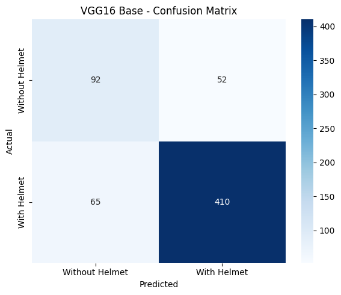

```python
# 4. Evaluate the VGG16 base model on the validation set

vgg16_base_pr_auc = plot_training_history(history_vgg16_base, "VGG16 Base")

vgg16_base_results = evaluate_model( vgg16_base_model,  X_val_norm,  y_val,  "VGG16 Base")
```

**VGG16 Base — Performance Summary**

- Compared to the baseline CNN model, the VGG16 Base model produced weaker overall performance across all key evaluation metrics.
- Validation PR-AUC remained strong during training, peaking at **0.9755**, while both training and validation loss decreased steadily, indicating stable learning behaviour.
- However, final classification performance on the critical **Without Helmet** class was lower than the CNN baseline, with recall dropping to **0.6389** and F1-score reducing to **0.6113**.
- Precision for the **Without Helmet** class reached **0.5860**, indicating a higher level of misclassification compared to the CNN model.
- The confusion matrix showed that the model struggled more with unsafe-worker detection, missing a larger proportion of non-helmet cases relative to the baseline CNN.
- Overall, although the pretrained VGG16 feature extractor learned meaningful representations, the simple output architecture was less effective than the CNN model for this dataset.

#### Visualizing the predictions

```
20/20 ━━━━━━━━━━━━━━━━━━━━ 3s 152ms/step
```

[figure not shown]

```python
visualize_predictions(vgg16_base_model, X_val_norm, y_val, class_names)
```

**VGG16 Base — Prediction Visualisation Summary**

- The VGG16 Base model correctly identified several clear helmet images, particularly in structured and well-lit scenes.
- However, the model struggled with a number of **Without Helmet** cases, incorrectly classifying unsafe workers as wearing helmets.
- Misclassifications were more common in blurred, low-resolution, and partially obstructed images where facial and head features were less distinct.
- The model appeared biased towards predicting the majority **With Helmet** class, contributing to lower recall for unsafe-worker detection.
- Overall, the visual predictions aligned with the weaker quantitative performance observed relative to the baseline CNN model.

To improve upon the weaker performance of the baseline VGG16 model, a deeper feedforward neural network (FFNN) classifier was added on top of the pretrained VGG16 feature extractor to improve feature separation and strengthen minority‑class recall. The objective was to enhance the model’s ability to learn more complex helmet and non-helmet feature representations while retaining the benefits of transfer learning.

### Model 3: Transfer Learning with VGG-16 (Base + FFNN)

Building on the VGG16 Base setup, the classifier is expanded into a deeper Feed-Forward Neural Network (FFNN) while retaining the frozen VGG16 backbone, giving the model greater capacity to learn task-specific patterns and better separate challenging Without Helmet cases.

```python
# Define Model 3: VGG16 Base + FFNN

# 1. Define model
vgg_ffnn_model = Sequential([
    vgg_model,
    Flatten(),

    Dense(128, activation="relu"),
    Dropout(0.4),

    Dense(64, activation="relu"),
    Dropout(0.3),

    Dense(1, activation="sigmoid")
])

vgg_ffnn_model.summary()

# 2. Compile Model 3
vgg_ffnn_model.compile(
    optimizer=Adam(learning_rate=learning_rate, clipnorm=1.0),
    loss=loss,
    metrics=['recall', AUC(name="pr_auc", curve="PR") ]
)

# 3. Train Model 3
history_vgg_ffnn = vgg_ffnn_model.fit(
    X_train_norm,
    y_train,
    validation_data=(X_val_norm, y_val),
    epochs=epochs,
    batch_size=batch_size,
    callbacks=[early_stop],
    verbose=2
)
```

```
Model: "sequential_2"
```

```
┏━━━━━━━━━━━━━━━━━━━━━━━━━━━━━━━━━┳━━━━━━━━━━━━━━━━━━━━━━━━┳━━━━━━━━━━━━━━━┓
┃ Layer (type)                    ┃ Output Shape           ┃       Param # ┃
┡━━━━━━━━━━━━━━━━━━━━━━━━━━━━━━━━━╇━━━━━━━━━━━━━━━━━━━━━━━━╇━━━━━━━━━━━━━━━┩
│ vgg16 (Functional)              │ (None, 6, 6, 512)      │    14,714,688 │
├─────────────────────────────────┼────────────────────────┼───────────────┤
│ flatten_2 (Flatten)             │ (None, 18432)          │             0 │
├─────────────────────────────────┼────────────────────────┼───────────────┤
│ dense_3 (Dense)                 │ (None, 128)            │     2,359,424 │
├─────────────────────────────────┼────────────────────────┼───────────────┤
│ dropout_1 (Dropout)             │ (None, 128)            │             0 │
├─────────────────────────────────┼────────────────────────┼───────────────┤
│ dense_4 (Dense)                 │ (None, 64)             │         8,256 │
├─────────────────────────────────┼────────────────────────┼───────────────┤
│ dropout_2 (Dropout)             │ (None, 64)             │             0 │
├─────────────────────────────────┼────────────────────────┼───────────────┤
│ dense_5 (Dense)                 │ (None, 1)              │            65 │
└─────────────────────────────────┴────────────────────────┴───────────────┘
```

```
 Total params: 17,082,433 (65.16 MB)
```

```
 Trainable params: 2,367,745 (9.03 MB)
```

```
 Non-trainable params: 14,714,688 (56.13 MB)
```

```
91/91 - 22s - 238ms/step - loss: 0.8977 - pr_auc: 0.8203 - recall: 0.8223 - val_loss: 0.5492 - val_pr_auc: 0.9476 - val_recall: 1.0000
91/91 - 19s - 208ms/step - loss: 0.8064 - pr_auc: 0.8703 - recall: 0.8540 - val_loss: 0.3209 - val_pr_auc: 0.9691 - val_recall: 0.9663
91/91 - 19s - 209ms/step - loss: 0.7608 - pr_auc: 0.8945 - recall: 0.8612 - val_loss: 0.4228 - val_pr_auc: 0.9711 - val_recall: 0.9874
91/91 - 19s - 208ms/step - loss: 0.6957 - pr_auc: 0.9081 - recall: 0.8757 - val_loss: 0.4012 - val_pr_auc: 0.9666 - val_recall: 0.9874
91/91 - 19s - 212ms/step - loss: 0.5895 - pr_auc: 0.9317 - recall: 0.8883 - val_loss: 0.4155 - val_pr_auc: 0.9691 - val_recall: 0.9895
```

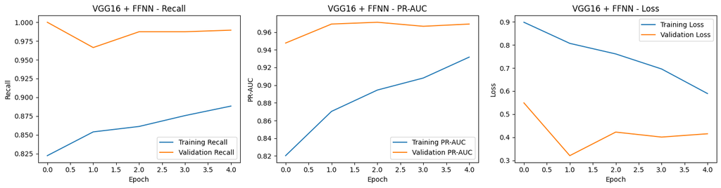

```
Best Validation PR-AUC (VGG16 + FFNN): 0.9711
20/20 ━━━━━━━━━━━━━━━━━━━━ 3s 160ms/step

Model: VGG16 + FFNN
Best Threshold (Without Helmet): 0.10
PR-AUC :        0.6622
ROC-AUC :       0.8504
Recall (Without Helmet):        0.6944
F1 Score (Without Helmet):      0.6042
Precision (Without Helmet):     0.5348

Classification Report:
                precision    recall  f1-score   support

Without Helmet       0.53      0.69      0.60       144
   With Helmet       0.90      0.82      0.86       475

      accuracy                           0.79       619
     macro avg       0.72      0.76      0.73       619
  weighted avg       0.81      0.79      0.80       619
```

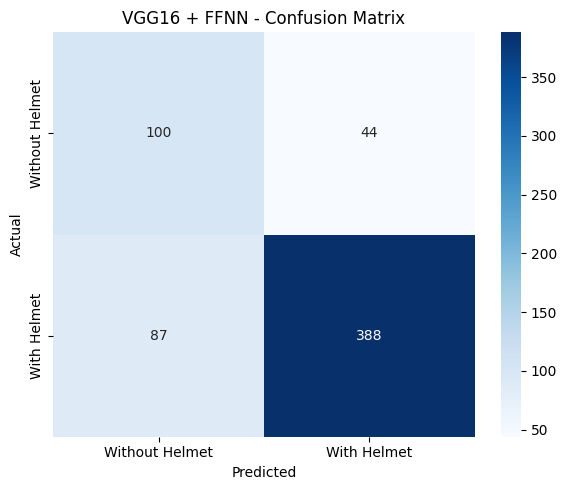

```python
# 4. Evaluate the VGG16 + FFNN model on the validation set

vgg_ffnn_pr_auc = plot_training_history(history_vgg_ffnn, "VGG16 + FFNN")

vgg_ffnn_results = evaluate_model( vgg_ffnn_model, X_val_norm, y_val, "VGG16 + FFNN")
```

**VGG16 + FFNN — Performance Summary**

- Adding the FFNN classifier improved unsafe-worker detection compared to the baseline VGG16 model, increasing recall for the **Without Helmet** class from **0.6389** to **0.6944**.
- Validation PR-AUC remained strong at **0.9711**, indicating stable class separation performance throughout training.
- Despite the improvement in recall, precision for the **Without Helmet** class reduced to **0.5348**, showing an increase in false positive predictions.
- The confusion matrix showed that the model detected more unsafe-worker cases than the baseline VGG16 model, although misclassification of safe workers also increased.
- Overall accuracy decreased slightly to **79%**, while the F1-score for the **Without Helmet** class remained moderate at **0.6042**.
- Compared to the CNN baseline, the VGG16 + FFNN model still produced weaker overall performance, particularly in balancing unsafe-worker detection with prediction reliability.

#### Visualizing the predictions

```
20/20 ━━━━━━━━━━━━━━━━━━━━ 3s 155ms/step
```

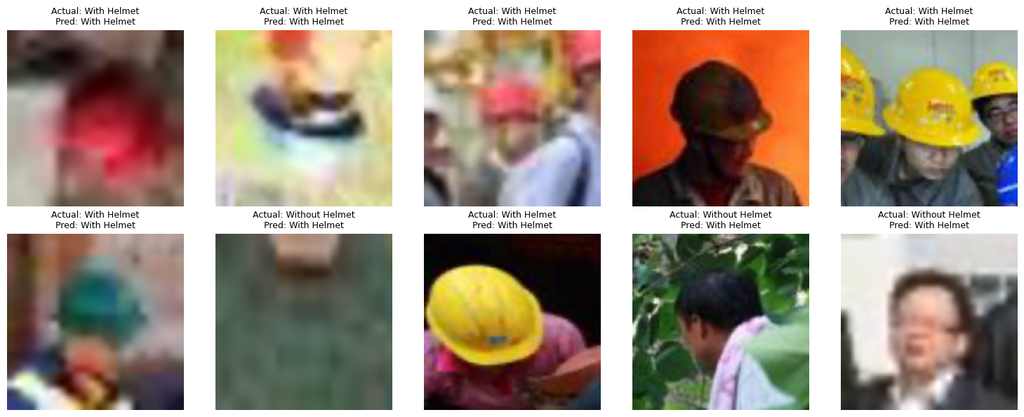

```python
# Visualise predictions

visualize_predictions( vgg_ffnn_model,   X_val_norm,   y_val, class_names )
```

**VGG16 + FFNN — Prediction Visualisation Summary**

- The VGG16 + FFNN model showed improved detection of non-helmet cases compared to the baseline VGG16 model.
- Several helmet images were correctly classified despite variations in lighting, background clutter, and viewing angles.
- The model still struggled with some blurred and low-resolution non-helmet images, incorrectly predicting them as helmet cases.
- False positive predictions increased, indicating that the deeper FFNN classifier improved sensitivity but reduced prediction reliability.
- Overall, the model demonstrated stronger feature learning than the baseline VGG16 model but still underperformed relative to the CNN baseline.

To further improve generalisation and robustness, data augmentation techniques were introduced alongside the VGG16 + FFNN architecture to expose the model to a wider range of image variations during training to improve robustness and further strengthen minority‑class recall under challenging visual conditions.

### Model 4: Transfer Learning with VGG-16 (Base + FFNN + Data Augmentation)

To further improve robustness and strengthen minority-class detection, this model keeps the **VGG16 + FFNN** architecture but introduces targeted data augmentation to increase visual variation and help the network generalise to unseen workplace conditions. Since collecting large numbers of new helmet images is difficult, augmentation expands the training distribution using the existing dataset, while only the training set is augmented—validation and test data remain unchanged to ensure fair, unbiased evaluation.

```python
# Define Model 4: VGG16 + FFNN + Data Augmentation

vgg_aug_model = Sequential([
    vgg_model,             # Adding the convolutional part of the VGG16 model from above
    Flatten(),             # Flattening the output of the VGG16 model because it is from a convolutional layer
     #Adding the Feed Forward neural network
    Dense(128,activation='relu'),
    Dropout(rate=0.4),
    Dense(64, activation="relu"),
    Dropout(0.3),

    # Adding a dense output layer
    Dense(1, activation='sigmoid')
])

# Compile model
vgg_aug_model.compile(
    optimizer=Adam(learning_rate= learning_rate,clipnorm=1.0),
    loss=loss,
    metrics=['recall', AUC(name="pr_auc", curve="PR") ]
)

# Generating the summary of the model
vgg_aug_model.summary()


# Applying data augmentation
train_datagen = ImageDataGenerator(
                              rotation_range=20,
                              fill_mode='nearest',width_shift_range=0.1,height_shift_range=0.1,shear_range=0.1,zoom_range=0.1
                              )

history_vgg_aug = vgg_aug_model.fit(train_datagen.flow(X_train_norm,y_train,
                                       batch_size=batch_size,
                                       seed=42,
                                       shuffle=False),
                    epochs=epochs,
                    validation_data=(X_val_norm,y_val),
                    callbacks=[early_stop],
                    verbose=1)
```

```
Model: "sequential_3"
```

```
┏━━━━━━━━━━━━━━━━━━━━━━━━━━━━━━━━━┳━━━━━━━━━━━━━━━━━━━━━━━━┳━━━━━━━━━━━━━━━┓
┃ Layer (type)                    ┃ Output Shape           ┃       Param # ┃
┡━━━━━━━━━━━━━━━━━━━━━━━━━━━━━━━━━╇━━━━━━━━━━━━━━━━━━━━━━━━╇━━━━━━━━━━━━━━━┩
│ vgg16 (Functional)              │ (None, 6, 6, 512)      │    14,714,688 │
├─────────────────────────────────┼────────────────────────┼───────────────┤
│ flatten_3 (Flatten)             │ (None, 18432)          │             0 │
├─────────────────────────────────┼────────────────────────┼───────────────┤
│ dense_6 (Dense)                 │ (None, 128)            │     2,359,424 │
├─────────────────────────────────┼────────────────────────┼───────────────┤
│ dropout_3 (Dropout)             │ (None, 128)            │             0 │
├─────────────────────────────────┼────────────────────────┼───────────────┤
│ dense_7 (Dense)                 │ (None, 64)             │         8,256 │
├─────────────────────────────────┼────────────────────────┼───────────────┤
│ dropout_4 (Dropout)             │ (None, 64)             │             0 │
├─────────────────────────────────┼────────────────────────┼───────────────┤
│ dense_8 (Dense)                 │ (None, 1)              │            65 │
└─────────────────────────────────┴────────────────────────┴───────────────┘
```

```
 Total params: 17,082,433 (65.16 MB)
```

```
 Trainable params: 2,367,745 (9.03 MB)
```

```
 Non-trainable params: 14,714,688 (56.13 MB)
```

```
91/91 ━━━━━━━━━━━━━━━━━━━━ 30s 319ms/step - loss: 0.7641 - pr_auc: 0.8406 - recall: 0.8431 - val_loss: 0.3748 - val_pr_auc: 0.9574 - val_recall: 0.9853
91/91 ━━━━━━━━━━━━━━━━━━━━ 29s 315ms/step - loss: 0.9541 - pr_auc: 0.8394 - recall: 0.8418 - val_loss: 0.4561 - val_pr_auc: 0.9648 - val_recall: 0.9958
91/91 ━━━━━━━━━━━━━━━━━━━━ 29s 319ms/step - loss: 0.9827 - pr_auc: 0.8536 - recall: 0.8476 - val_loss: 0.4957 - val_pr_auc: 0.9642 - val_recall: 0.9958
91/91 ━━━━━━━━━━━━━━━━━━━━ 28s 310ms/step - loss: 0.8770 - pr_auc: 0.8793 - recall: 0.8599 - val_loss: 0.4011 - val_pr_auc: 0.9709 - val_recall: 0.9853
91/91 ━━━━━━━━━━━━━━━━━━━━ 28s 310ms/step - loss: 0.8638 - pr_auc: 0.8942 - recall: 0.8526 - val_loss: 0.3576 - val_pr_auc: 0.9664 - val_recall: 0.9705
```

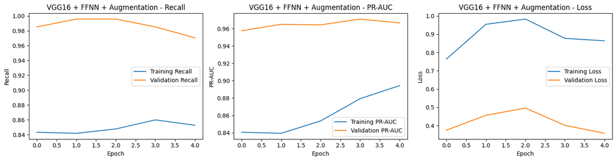

```
Best Validation PR-AUC (VGG16 + FFNN + Augmentation): 0.9709
20/20 ━━━━━━━━━━━━━━━━━━━━ 4s 168ms/step

Model: VGG16 + FFNN + Augmentation
Best Threshold (Without Helmet): 0.25
PR-AUC :        0.7051
ROC-AUC :       0.8778
Recall (Without Helmet):        0.7917
F1 Score (Without Helmet):      0.6264
Precision (Without Helmet):     0.5182

Classification Report:
                precision    recall  f1-score   support

Without Helmet       0.52      0.79      0.63       144
   With Helmet       0.92      0.78      0.84       475

      accuracy                           0.78       619
     macro avg       0.72      0.78      0.74       619
  weighted avg       0.83      0.78      0.79       619
```

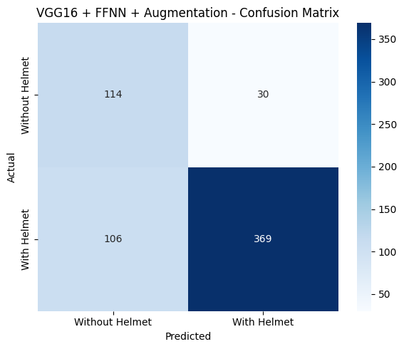

```python
# 5. Evaluate the VGG16 + FFNN + Augmentation model on the validation set

vgg_aug_pr_auc = plot_training_history(history_vgg_aug, "VGG16 + FFNN + Augmentation")

vgg_aug_results = evaluate_model( vgg_aug_model, X_val_norm, y_val, "VGG16 + FFNN + Augmentation")
```

#### Visualizing the predictions

```
20/20 ━━━━━━━━━━━━━━━━━━━━ 3s 158ms/step
```

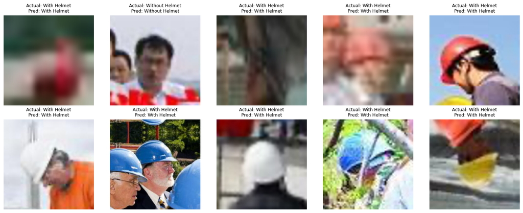

```python
# Visualise predictions
visualize_predictions( vgg_aug_model, X_val_norm,  y_val,class_names)
```

**VGG16 + FFNN + Augmentation – Prediction Summary**

- The augmented VGG16 + FFNN model showed stronger detection of non-helmet cases compared to the earlier VGG16-based models.
- The model handled variations in lighting, viewing angles, background clutter, and helmet colours more effectively after augmentation was introduced.
- Several difficult and low-quality helmet images were still classified correctly, indicating improved robustness and generalisation capability.
- The model produced more aggressive unsafe-worker detection behaviour, which improved recall but also increased false positive predictions.
- Overall, data augmentation enhanced the model’s sensitivity to helmet-related visual patterns and improved performance relative to the previous VGG16 architectures.

## **Model Performance Comparison and Final Model Selection**

### Model Performance Comparison

```python
# Evaluate all models : High recall + High Precision Best model

all_results = [
    cnn_results,
    vgg16_base_results,
    vgg_ffnn_results,
    vgg_aug_results
]

results_df = pd.DataFrame([
    {
        "Model": r["model_name"],
        "Threshold": round(r["threshold"], 2),
        "Recall (No Helmet)": round(r["recall"], 3),
        "Precision (No Helmet)": round(r["precision"], 3),
        "F1 (No Helmet)": round(r["f1"], 3),
        "PR-AUC": round(r["pr_auc"], 3),
        "ROC-AUC": round(r["roc_auc"], 3),
        "TN": r["tn"],
        "FP": r["fp"],
        "FN": r["fn"],
        "TP": r["tp"]
    }
    for r in all_results
])

# Prioritise strong unsafe-worker detection while limiting false alarms.
# Recall is primary, PR-AUC measures class separation,
# and F1 balances recall with precision.

results_df = results_df.sort_values(
    by=["PR-AUC","Recall (No Helmet)",  "F1 (No Helmet)", "Precision (No Helmet)"],
    ascending=[False, False, False, False]
).reset_index(drop=True)

results_df
```

|  | Model | Threshold | Recall (No Helmet) | Precision (No Helmet) | F1 (No Helmet) | PR-AUC | ROC-AUC | TN | FP | FN | TP |
| --- | --- | --- | --- | --- | --- | --- | --- | --- | --- | --- | --- |
| 0 | CNN | 0.10 | 0.924 | 0.739 | 0.821 | 0.894 | 0.964 | 133 | 11 | 47 | 428 |
| 1 | VGG16 + FFNN + Augmentation | 0.25 | 0.792 | 0.518 | 0.626 | 0.705 | 0.878 | 114 | 30 | 106 | 369 |
| 2 | VGG16 + FFNN | 0.10 | 0.694 | 0.535 | 0.604 | 0.662 | 0.850 | 100 | 44 | 87 | 388 |
| 3 | VGG16 Base | 0.30 | 0.639 | 0.586 | 0.611 | 0.661 | 0.868 | 92 | 52 | 65 | 410 |

**Model Performance Comparison**

The **CNN from Scratch** performed strongest overall. It achieved the best balance between detecting workers without helmets and maintaining reliable predictions, with strong recall, F1-score, and precision.

The **VGG16 Base** model showed weaker performance, suggesting that pretrained VGG16 features with only a simple Dense output layer were not sufficient for this dataset.

The **VGG16 + FFNN** model improved detection compared with the VGG16 Base model, but still did not outperform the CNN baseline.

The **VGG16 + FFNN + Augmentation** model improved recall among the VGG16 models, showing that augmentation helped the model detect more unsafe cases. However, its precision remained lower, meaning it produced more false alarms.

### Selected Model

```python
# Select the best model based on the evaluation results

best_model_name = results_df.iloc[0]["Model"]
best_model_name

model_lookup = {
    "CNN": cnn_model,
    "VGG16 Base": vgg16_base_model,
    "VGG16 + FFNN": vgg_ffnn_model,
    "VGG16 + FFNN + Augmentation": vgg_aug_model
}

best_model = model_lookup[best_model_name]
print(f"Selected model for final testing: {best_model_name}")
```

```
Selected model for final testing: CNN
```

**Selected Model**

The **CNN Model** was selected as the final model because it provided the most balanced and reliable performance for the project objective: identifying workers without helmets while avoiding excessive misclassification of safe workers.

### Test Performance

```
20/20 ━━━━━━━━━━━━━━━━━━━━ 0s 15ms/step

Model: Final Model - Test Set
Best Threshold (Without Helmet): 0.10
PR-AUC :        0.8872
ROC-AUC :       0.9625
Recall (Without Helmet):        0.9172
F1 Score (Without Helmet):      0.8036
Precision (Without Helmet):     0.7151

Classification Report:
                precision    recall  f1-score   support

Without Helmet       0.72      0.92      0.80       145
   With Helmet       0.97      0.89      0.93       474

      accuracy                           0.89       619
     macro avg       0.84      0.90      0.87       619
  weighted avg       0.91      0.89      0.90       619
```

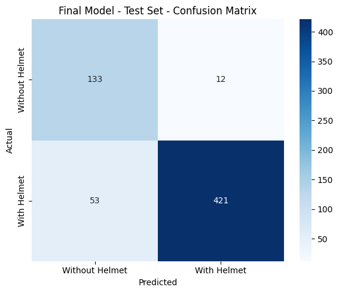

```
   Recall (No Helmet)  Precision (No Helmet)  F1 (No Helmet)  PR-AUC  ROC-AUC  \
0               0.917                  0.715           0.804   0.887    0.963

   Threshold
0        0.1
```

```python
# Test the best model on the unseen test set to evaluate its generalization performance and ensure that it maintains high recall for the "Without Helmet" class while keeping the FPR low on new, unseen data.

final_results = evaluate_model(
    best_model,
    X_test_norm,
    y_test,
    "Final Model - Test Set"
)

print(pd.DataFrame([{
    "Recall (No Helmet)": round(final_results["recall"], 3),
    "Precision (No Helmet)": round(final_results["precision"], 3),
    "F1 (No Helmet)": round(final_results["f1"], 3),
    "PR-AUC": round(final_results["pr_auc"], 3),
    "ROC-AUC": round(final_results["roc_auc"], 3),
    "Threshold": round(final_results["threshold"], 2)
}]))
```

**Final Model Evaluation – Test Set**

- The selected CNN from Scratch model maintained strong performance on the unseen test dataset, demonstrating good generalisation capability beyond the validation stage.
- The model achieved a **Recall (Without Helmet)** score of **0.9172**, showing that most unsafe-worker cases were successfully detected. Precision for the **Without Helmet** class reached **0.7151**, indicating a reasonable balance between detecting unsafe workers and limiting false alarms.
- The model produced an **F1-score** of **0.8036**, confirming a strong balance between recall and precision for the safety-critical class. In addition, the model achieved a **PR-AUC** of **0.8872** and a **ROC-AUC** of **0.9625**, demonstrating strong overall classification capability.
- The confusion matrix further showed that the model correctly identified the majority of both helmet and non-helmet cases, with relatively few missed unsafe-worker predictions.

**Overall, the final CNN model demonstrated the most reliable and balanced performance for practical helmet-detection deployment.**

## **Actionable Insights & Recommendations**

- The primary objective of this project was to accurately identify workers **without helmets (Class 0)** while minimising critical unsafe-worker misclassifications. Based on the evaluation results, the CNN model achieved the strongest balance between safety detection performance and overall prediction reliability.
- The final CNN model achieved strong recall for the **Without Helmet** class, indicating that most unsafe workers were successfully detected under varying workplace conditions.
- In the context of this project:
  - **False Positives (FP)** represent workers **without helmets incorrectly classified as wearing helmets**, making them the most critical safety-related error because unsafe workers may go undetected.
  - **False Negatives (FN)** represent workers **wearing helmets incorrectly classified as not wearing helmets**, which may create unnecessary alerts or inspections but still maintain a safer operational outcome.
- The final model produced a relatively low number of critical false positives compared to the total number of unsafe-worker detections achieved, indicating that the model maintained strong safety-focused performance.
- Most false positive cases occurred in blurred, low-resolution, partially obstructed, or poorly lit images where helmet-related visual features were difficult to distinguish clearly.
- False Negatives were also present, meaning some workers wearing helmets were incorrectly flagged as unsafe. However, from a workplace safety perspective, these are generally considered less critical than false positives because they trigger additional inspection rather than allowing unsafe behaviour to go undetected.
- The VGG16-based models demonstrated that pretrained transfer-learning architectures can support helmet detection tasks effectively, while the addition of FFNN layers and augmentation improved robustness and sensitivity under more varied image conditions.
- The results showed that image quality and dataset diversity strongly influenced performance. Future improvements should focus on collecting more diverse workplace images covering different helmet colours, worker poses, lighting conditions, camera angles, and partially visible workers.
- Additional experimentation with advanced augmentation strategies, fine-tuning pretrained CNN backbones, and alternative transfer-learning architectures such as ResNet50, EfficientNet, DenseNet, and MobileNet may further reduce critical false positive rates and improve unsafe-worker detection performance.
- Future work could extend this solution into a real-time workplace safety monitoring system capable of analysing live video streams, generating automated alerts, and supporting proactive health-and-safety compliance monitoring.